# Notebook report

## Core Team A3: Homework 6

Shaina Raskin, Elmer Camargopena, Kevin Wolfman, Raghav Bansal, Ilayda Sekercioglu, Kyuyeon Min

Date: 11/11/22

Homeruns Division Salaries

### 1. Make a plot of salaries versus 1986 home runs. What do you observe?

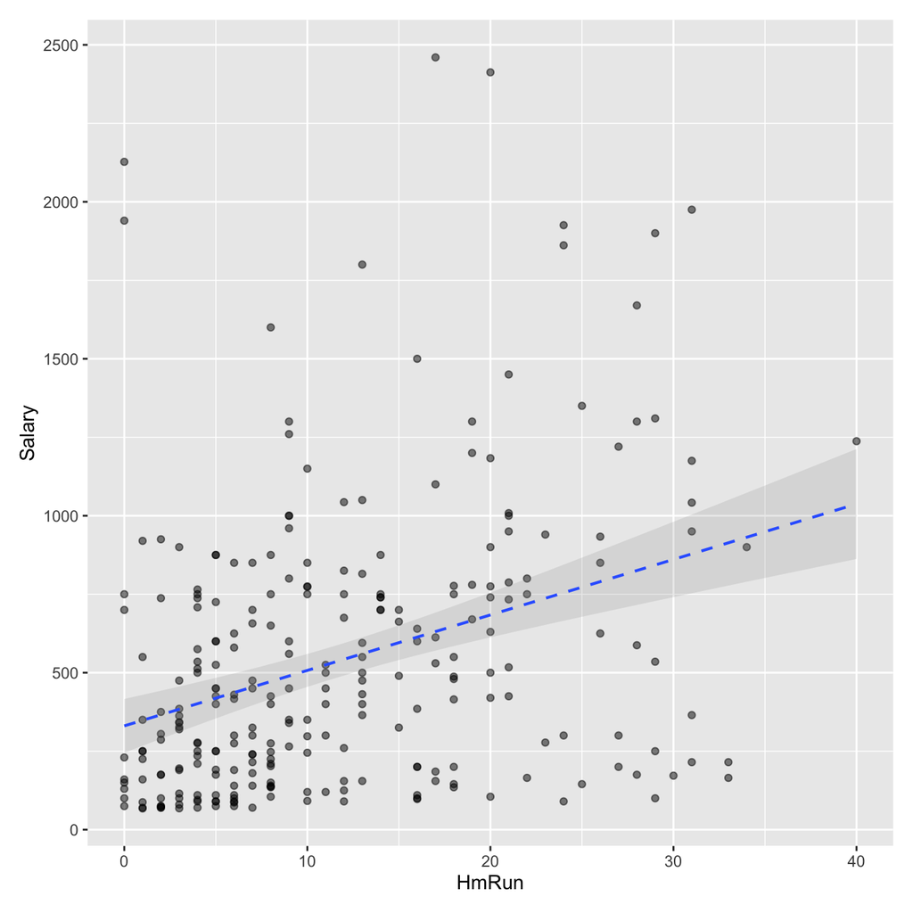

```r
visualize(
  baseball,
  xvar = "HmRun",
  yvar = "Salary",
  type = "scatter",
  nrobs = -1,
  check = "line",
  custom = FALSE
)
```

From the plot we see that the more home runs that a person hits the salary trends up however, the data is all over the place.

### 3. Is there evidence at the 0.05 level that home runs is a statistically significant feature in this model? Justify your answer.

A model predicting salary based on homeruns:

```r
result <- regress(
  baseball,
  rvar = "Salary",
  evar = "HmRun",
  data_filter = "training==1"
)
summary(result)
```

```
Linear regression (OLS)
Data     : baseball
Filter   : training==1
Response variable    : Salary
Explanatory variables: HmRun
Null hyp.: the effect of HmRun on Salary is zero
Alt. hyp.: the effect of HmRun on Salary is not zero

             coefficient std.error t.value p.value
 (Intercept)     388.809    54.151   7.180  < .001 ***
 HmRun            13.466     3.851   3.497  < .001 ***

Signif. codes:  0 '***' 0.001 '**' 0.01 '*' 0.05 '.' 0.1 ' ' 1

R-squared: 0.063,  Adjusted R-squared: 0.058
F-statistic: 12.229 df(1,182), p.value 0.001
Nr obs: 184
```

There is evidence that home runs is statistically significant in this model because the p-value is less than .05.

### 4. What are the units of βHmRun in this model?

The units of this model are in the thousands of dollars.

### 6. Is 0 included in the confidence interval from Problem 5? Explain how you could have answered this question without even looking at the confidence interval itself.

Zero is not included within the confidence interval because the p-value is less than .05 which means that null is voided and the impact on Salary is not 0.

### 7. Now fit a model that includes runs in addition to home runs. Provide the output.

```r
result <- regress(
  baseball,
  rvar = "Salary",
  evar = c("HmRun", "Runs"),
  data_filter = "training==1"
)
summary(result)
```

```
Linear regression (OLS)
Data     : baseball
Filter   : training==1
Response variable    : Salary
Explanatory variables: HmRun, Runs
Null hyp.: the effect of x on Salary is zero
Alt. hyp.: the effect of x on Salary is not zero

             coefficient std.error t.value p.value
 (Intercept)     129.790    72.448   1.792   0.075 .
 HmRun             0.317     4.466   0.071   0.943
 Runs              7.424     1.478   5.022  < .001 ***

Signif. codes:  0 '***' 0.001 '**' 0.01 '*' 0.05 '.' 0.1 ' ' 1

R-squared: 0.178,  Adjusted R-squared: 0.168
F-statistic: 19.536 df(2,181), p.value < .001
Nr obs: 184
```

### 8. Is there evidence at the 0.05 level that home runs is a statistically significant feature in this model? Justify your answer.

`Runs` is statistically significant in our model given that the p-value is < .05

### 9. Relate your answers in Problems 3 and 8 to each other and explain what may be happening. Make a plot to help in your explanation.

Given that `HmRun` and`Runs` are correlated, it could be that `Runs` provides stronger explanatory power than `HmRun`.

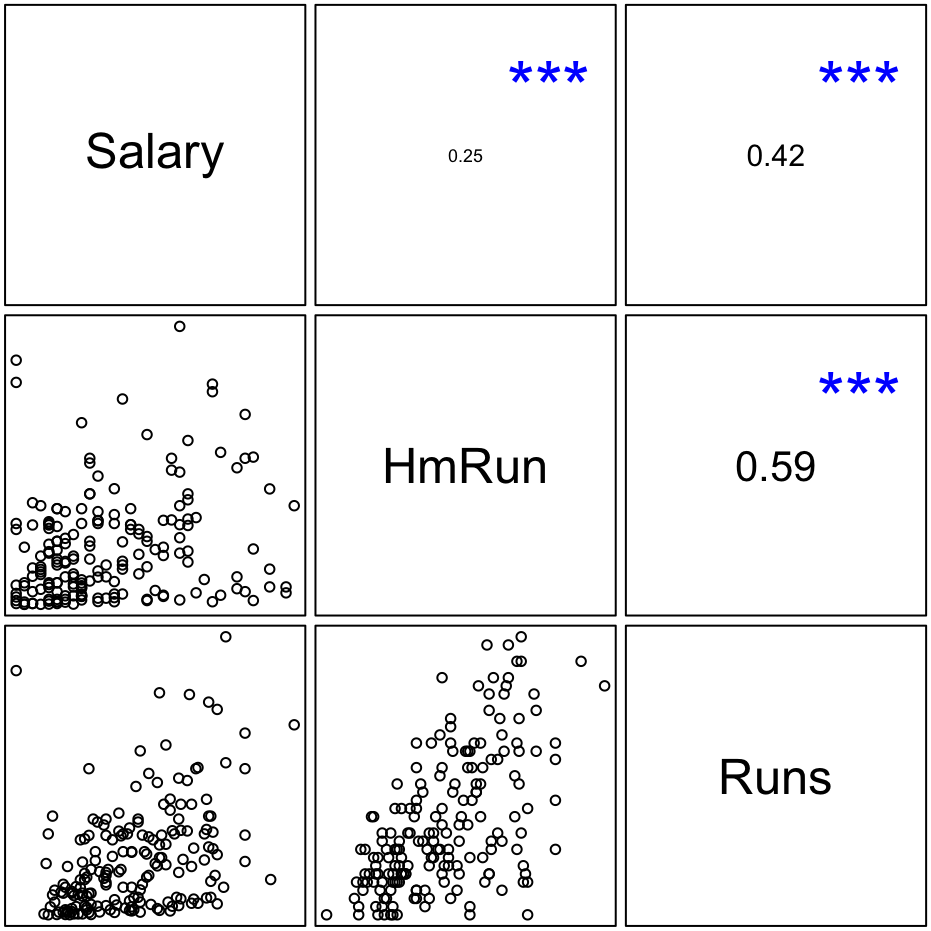

```r
plot(result, plots = "correlations", nrobs = -1, custom = FALSE)
```

### 10. Add a column called pred_hmrun to the data set that has the predicted salaries using the model in Problem 2. Include in this answer the Radiant output you get after clicking “Store predictions.” For the first hitter in the dataset, give the actual salary, predicted salary, and how far off the prediction is from the actual value. Was this hitter in the training set or the test set?

```r
result <- regress(
  baseball,
  rvar = "Salary",
  evar = "HmRun",
  data_filter = "training==1"
)

pred <- predict(result, pred_data = baseball)
print(pred, n = 10)
```

```
Linear regression (OLS)
Data                 : baseball
Filter               : training==1
Response variable    : Salary
Explanatory variables: HmRun
Interval             : confidence
Prediction dataset   : baseball
Rows shown           : 10 of 263

  HmRun Prediction    2.5%   97.5%     +/-
  7.000    483.072 411.232 554.912  71.840
 18.000    631.200 548.967 713.433  82.233
 20.000    658.132 565.642 750.622  92.490
 10.000    523.470 458.569 588.372  64.902
  4.000    442.673 358.123 527.224  84.551
  1.000    402.275 301.400 503.150 100.875
  0.000    388.809 281.965 495.653 106.844
  6.000    469.606 394.054 545.158  75.552
 17.000    617.733 540.020 695.447  77.714
 21.000    671.598 573.498 769.698  98.100
```

```r
baseball <- store(baseball, pred, name = "pred_HmRun")
```

```r
## filter and sort the dataset
baseball %>%
  select(Salary:resids_HmRun) %>%
  dtab(dec = 2, nr = 1) %>% render()
```

[output not shown]

### 11. Now, perform backward stepwise regression, where you start with all features in the model (but be sure not to include the variables training and pred_hmrun, which are columns in our data set that are not actually features!). Show the output.

```r
result <- regress(
  baseball,
  rvar = "Salary",
  evar = c(
    "AtBat", "Hits", "HmRun", "Runs", "RBI", "Walks", "Years",
    "CAtBat", "CHits", "CHmRun", "CRuns", "CRBI", "CWalks",
    "League", "Division", "PutOuts", "Assists", "NewLeague",
    "Errors"
  ),
  check = "stepwise-backward",
  data_filter = "training==1"
)
```

```
Start:  AIC=2134.7
Salary ~ AtBat + Hits + HmRun + Runs + RBI + Walks + Years +
    CAtBat + CHits + CHmRun + CRuns + CRBI + CWalks + League +
    Division + PutOuts + Assists + NewLeague + Errors

            Df Sum of Sq      RSS    AIC
- RBI        1       429 16178791 2132.7
- Runs       1       430 16178792 2132.7
- Years      1      1137 16179499 2132.7
- CHits      1      9493 16187855 2132.8
- CAtBat     1     18878 16197240 2132.9
- Errors     1     32885 16211247 2133.1
- CHmRun     1     33302 16211664 2133.1
- CRBI       1     46643 16225005 2133.2
- League     1     54689 16233051 2133.3
- HmRun      1     62635 16240998 2133.4
- NewLeague  1    170551 16348913 2134.6
<none>                   16178362 2134.7
- Assists    1    292603 16470965 2136.0
- Division   1    297505 16475867 2136.1
- CRuns      1    317824 16496187 2136.3
- PutOuts    1    389633 16567996 2137.1
- Hits       1    402605 16580967 2137.2
- AtBat      1    504175 16682537 2138.3
- CWalks     1    619894 16798256 2139.6
- Walks      1   1178163 17356525 2145.6

Step:  AIC=2132.71
Salary ~ AtBat + Hits + HmRun + Runs + Walks + Years + CAtBat +
    CHits + CHmRun + CRuns + CRBI + CWalks + League + Division +
    PutOuts + Assists + NewLeague + Errors

            Df Sum of Sq      RSS    AIC
- Runs       1       637 16179428 2130.7
- Years      1      1090 16179881 2130.7
- CHits      1      9212 16188003 2130.8
- CAtBat     1     18597 16197388 2130.9
- Errors     1     33280 16212071 2131.1
- CHmRun     1     36836 16215627 2131.1
- CRBI       1     49430 16228221 2131.3
```

[output cut: 164 more lines]

```
Salary ~ AtBat + Hits + HmRun + Walks + CHmRun + CRuns + CWalks +
    Division + PutOuts + Assists

           Df Sum of Sq      RSS    AIC
<none>                  16556986 2121.0
- HmRun     1    229530 16786517 2121.5
- Assists   1    276130 16833117 2122.0
- PutOuts   1    402152 16959139 2123.4
- Division  1    420645 16977632 2123.6
- AtBat     1    766263 17323250 2127.3
- CWalks    1    907954 17464940 2128.8
- Hits      1    911699 17468686 2128.8
- CHmRun    1   1074047 17631034 2130.5
- CRuns     1   1369788 17926774 2133.6
- Walks     1   1971005 18527991 2139.7
```

```r
summary(result)
```

```
----------------------------------------------------
Backward stepwise selection of variables
----------------------------------------------------
Linear regression (OLS)
Data     : baseball
Filter   : training==1
Response variable    : Salary
Explanatory variables: AtBat, Hits, HmRun, Runs, RBI, Walks, Years, CAtBat, CHits, CHmRun, CRuns, CRBI, CWalks, League, Division, PutOuts, Assists, NewLeague, Errors
Null hyp.: the effect of x on Salary is zero
Alt. hyp.: the effect of x on Salary is not zero

             coefficient std.error t.value p.value
 (Intercept)      90.914    76.614   1.187   0.237
 AtBat            -1.934     0.683  -2.830   0.005 **
 Hits              6.224     2.017   3.086   0.002 **
 HmRun            -6.687     4.318  -1.549   0.123
 Walks             8.383     1.847   4.538  < .001 ***
 CHmRun            2.351     0.702   3.350  < .001 ***
 CRuns             0.934     0.247   3.783  < .001 ***
 CWalks           -0.948     0.308  -3.080   0.002 **
 Division|W      -98.177    46.830  -2.096   0.037 *
 PutOuts           0.185     0.090   2.050   0.042 *
 Assists           0.335     0.197   1.699   0.091 .

Signif. codes:  0 '***' 0.001 '**' 0.01 '*' 0.05 '.' 0.1 ' ' 1

R-squared: 0.563,  Adjusted R-squared: 0.537
F-statistic: 22.253 df(10,173), p.value < .001
Nr obs: 184
```

```r
pred <- predict(result, pred_data = baseball)
print(pred, n = 10)
```

```
Linear regression (OLS)
Data                 : baseball
Filter               : training==1
Response variable    : Salary
Explanatory variables: AtBat, Hits, HmRun, Walks, CHmRun, CRuns, CWalks, Division, PutOuts, Assists
Interval             : confidence
Prediction dataset   : baseball
Rows shown           : 10 of 263

   AtBat    Hits  HmRun    Runs    RBI  Walks  Years   CAtBat    CHits  CHmRun   CRuns    CRBI  CWalks League Division PutOuts Assists NewLeague Errors Prediction     2.5%    97.5%     +/-
 315.000  81.000  7.000  24.000 38.000 39.000 14.000 3449.000  835.000  69.000 321.000 414.000 375.000      N        W 632.000  43.000         N 10.000    406.122  290.336  521.908 115.786
 479.000 130.000 18.000  66.000 72.000 76.000  3.000 1624.000  457.000  63.000 224.000 266.000 263.000      A        W 880.000  82.000         A 14.000    691.071  553.541  828.601 137.530
 496.000 141.000 20.000  65.000 78.000 37.000 11.000 5628.000 1575.000 225.000 828.000 838.000 354.000      N        E 200.000  11.000         N  3.000   1193.424 1019.049 1367.799 174.375
 321.000  87.000 10.000  39.000 42.000 30.000  2.000  396.000  101.000  12.000  48.000  46.000  33.000      N        E 805.000  40.000         N  4.000    400.723  268.343  533.102 132.379
 594.000 169.000  4.000  74.000 51.000 35.000 11.000 4408.000 1133.000  19.000 501.000 336.000 194.000      A        W 282.000 421.000         A 25.000    684.853  541.480  828.226 143.373
 185.000  37.000  1.000  23.000  8.000 21.000  2.000  214.000   42.000   1.000  30.000   9.000  24.000      N        E  76.000 127.000         A  7.000    197.119   83.409  310.829 113.710
 298.000  73.000  0.000  24.000 24.000  7.000  3.000  509.000  108.000   0.000  41.000  37.000  12.000      A        W 121.000 283.000         A  9.000     73.770  -45.685  193.225 119.455
 323.000  81.000  6.000  26.000 32.000  8.000  2.000  341.000   86.000   6.000  32.000  34.000   8.000      N        W 143.000 290.000         N 19.000     59.393  -57.809  176.595 117.202
 401.000  92.000 17.000  49.000 66.000 65.000 13.000 5206.000 1332.000 253.000 784.000 890.000 866.000      A        E   0.000   0.000         A  0.000    825.637  586.158 1065.116 239.479
 574.000 159.000 21.000 107.000 75.000 59.000 10.000 4631.000 1300.000  90.000 702.000 504.000 488.000      A        E 238.000 445.000         A 22.000    922.909  763.976 1081.841 158.933
```

```r
baseball <- store(baseball, pred, name = "pred_step")
```

### 12. What were the first, second, and third features to be dropped?

1. `RBI`
2. `Runs`
3. `Years`

### 13. How many features remain in the selected model?

10 features

### 14. dd a column called pred_step to the data set that has the predicted salaries using the model selected by stepwise regression. For the first hitter in the dataset, give the actual salary, predicted salary, and how far off the prediction is from the actual value.

```r
## filter and sort the dataset
baseball %>%
  select(Salary, training, pred_step, resids_step) %>%
  dtab(dec = 2, nr = 1) %>% render()
```

| Salary | training | pred_step | resids_step |
| --- | --- | --- | --- |
| 475 | 1 | 406.12192622573 | 68.8780737742705 |

### 15. Make a table showing both the training and test errors for the pred_hmrun and pred_step models.

```r
result <- evalreg(
  baseball,
  pred = c("pred_HmRun", "pred_step"),
  rvar = "Salary",
  train = "Both",
  data_filter = "training==1"
)
summary(result)
```

```
Evaluate predictions for regression models
Data        : baseball
Filter      : training==1
Results for : Both
Predictors  : pred_HmRun, pred_step
Response    : Salary

     Type  Predictor   n   Rsq    RMSE     MAE
 Training pred_HmRun 184 0.063 439.064 335.266
 Training  pred_step 184 0.563 299.973 209.303
     Test pred_HmRun  79 0.302 388.969 281.545
     Test  pred_step  79 0.410 353.135 246.871
```

### 16. Which of these two models has a lower test mean absolute error (MAE)?

The stepwise regression model has a lower MAE in both the train and test sets

### 17. What are the units of the MAE in this problem?

The units are in `Salary` which is cash

### 18. Fit a neural network with 3 hidden units2 that uses all the variables (again, be sure to exclude the training and any columns you’ve created of predictions). Display the output.

```r
result <- nn(
  baseball,
  rvar = "Salary",
  evar = c(
    "AtBat", "Hits", "HmRun", "Runs", "RBI", "Walks", "Years",
    "CAtBat", "CHits", "CHmRun", "CRuns", "CRBI", "CWalks",
    "League", "Division", "PutOuts", "Assists", "NewLeague",
    "Errors"
  ),
  type = "regression",
  size = 3,
  seed = 1234,
  data_filter = "training==1"
)
summary(result, prn = TRUE)
```

```
Neural Network
Activation function  : Linear (regression)
Data                 : baseball
Filter               : training==1
Response variable    : Salary
Explanatory variables: AtBat, Hits, HmRun, Runs, RBI, Walks, Years, CAtBat, CHits, CHmRun, CRuns, CRBI, CWalks, League, Division, PutOuts, Assists, NewLeague, Errors
Network size         : 3
Parameter decay      : 0.5
Seed                 : 1234
Network              : 19-3-1 with 64 weights
Nr obs               : 184
Weights              :
    b->h1  i1->h1  i2->h1  i3->h1  i4->h1  i5->h1  i6->h1  i7->h1  i8->h1  i9->h1 i10->h1 i11->h1
     0.92   -0.52   -0.13    0.00   -0.14   -0.25   -0.07    0.40    0.51    0.60    0.35    0.62
  i12->h1 i13->h1 i14->h1 i15->h1 i16->h1 i17->h1 i18->h1 i19->h1
     0.51    0.55   -0.01   -0.08   -0.12    0.11    0.15   -0.05
    b->h2  i1->h2  i2->h2  i3->h2  i4->h2  i5->h2  i6->h2  i7->h2  i8->h2  i9->h2 i10->h2 i11->h2
     0.51   -0.23   -0.43    0.11   -0.35   -0.23   -0.52    0.17   -0.11   -0.27   -0.13   -0.29
  i12->h2 i13->h2 i14->h2 i15->h2 i16->h2 i17->h2 i18->h2 i19->h2
    -0.23   -0.12    0.26    0.20   -0.33    0.04    0.21   -0.14
    b->h3  i1->h3  i2->h3  i3->h3  i4->h3  i5->h3  i6->h3  i7->h3  i8->h3  i9->h3 i10->h3 i11->h3
    -0.51    0.02   -0.29    0.32   -0.35   -0.05   -0.13    0.95    0.39    0.10   -0.33   -0.01
  i12->h3 i13->h3 i14->h3 i15->h3 i16->h3 i17->h3 i18->h3 i19->h3
    -0.11    0.44   -0.26    0.01   -0.18   -0.05   -0.37    0.11
   b->o h1->o h2->o h3->o
   0.19  1.53 -1.14 -1.23
```

### 19. Include a picture of the network itself.

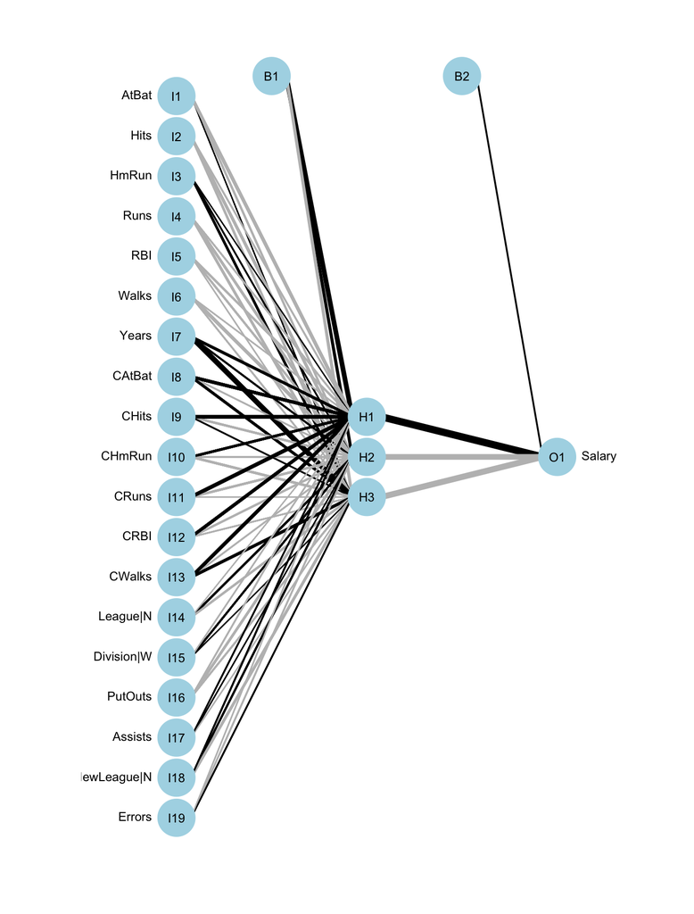

```r
plot(result, plots = "net", custom = FALSE)
```

### 20. Add a column of predictions called pred_nn3. Show the Radiant output you get after clicking “Store predictions.

```r
result <- nn(
  baseball,
  rvar = "Salary",
  evar = c(
    "AtBat", "Hits", "HmRun", "Runs", "RBI", "Walks", "Years",
    "CAtBat", "CHits", "CHmRun", "CRuns", "CRBI", "CWalks",
    "League", "Division", "PutOuts", "Assists", "NewLeague",
    "Errors"
  ),
  type = "regression",
  size = 3,
  seed = 1234,
  data_filter = "training==1"
)
pred <- predict(result, pred_data = baseball)
print(pred, n = 10)
```

```
Neural Network
Data                 : baseball
Filter               : training==1
Response variable    : Salary
Explanatory variables: AtBat, Hits, HmRun, Runs, RBI, Walks, Years, CAtBat, CHits, CHmRun, CRuns, CRBI, CWalks, League, Division, PutOuts, Assists, NewLeague, Errors
Prediction dataset   : baseball
Rows shown           : 10 of 263

   AtBat    Hits  HmRun    Runs    RBI  Walks  Years   CAtBat    CHits  CHmRun   CRuns    CRBI  CWalks League Division PutOuts Assists NewLeague Errors Prediction
 315.000  81.000  7.000  24.000 38.000 39.000 14.000 3449.000  835.000  69.000 321.000 414.000 375.000      N        W 632.000  43.000         N 10.000    555.630
 479.000 130.000 18.000  66.000 72.000 76.000  3.000 1624.000  457.000  63.000 224.000 266.000 263.000      A        W 880.000  82.000         A 14.000    640.427
 496.000 141.000 20.000  65.000 78.000 37.000 11.000 5628.000 1575.000 225.000 828.000 838.000 354.000      N        E 200.000  11.000         N  3.000   1178.126
 321.000  87.000 10.000  39.000 42.000 30.000  2.000  396.000  101.000  12.000  48.000  46.000  33.000      N        E 805.000  40.000         N  4.000    256.822
 594.000 169.000  4.000  74.000 51.000 35.000 11.000 4408.000 1133.000  19.000 501.000 336.000 194.000      A        W 282.000 421.000         A 25.000    705.216
 185.000  37.000  1.000  23.000  8.000 21.000  2.000  214.000   42.000   1.000  30.000   9.000  24.000      N        E  76.000 127.000         A  7.000    183.720
 298.000  73.000  0.000  24.000 24.000  7.000  3.000  509.000  108.000   0.000  41.000  37.000  12.000      A        W 121.000 283.000         A  9.000     75.598
 323.000  81.000  6.000  26.000 32.000  8.000  2.000  341.000   86.000   6.000  32.000  34.000   8.000      N        W 143.000 290.000         N 19.000    148.740
 401.000  92.000 17.000  49.000 66.000 65.000 13.000 5206.000 1332.000 253.000 784.000 890.000 866.000      A        E   0.000   0.000         A  0.000    933.322
 574.000 159.000 21.000 107.000 75.000 59.000 10.000 4631.000 1300.000  90.000 702.000 504.000 488.000      A        E 238.000 445.000         A 22.000   1117.357
```

```r
baseball <- store(baseball, pred, name = "pred_nn3")
```

### 21. Show the table of training and test errors with the results from this neural net included. How does the test MAE of this neural network compare to the two regression models?

```r
result <- evalreg(
  baseball,
  pred = c("pred_HmRun", "pred_step", "pred_nn3"),
  rvar = "Salary",
  train = "Both",
  data_filter = "training==1"
)
summary(result)
```

```
Evaluate predictions for regression models
Data        : baseball
Filter      : training==1
Results for : Both
Predictors  : pred_HmRun, pred_step, pred_nn3
Response    : Salary

     Type  Predictor   n   Rsq    RMSE     MAE
 Training pred_HmRun 184 0.063 439.064 335.266
 Training  pred_step 184 0.563 299.973 209.303
 Training   pred_nn3 184 0.692 254.124 169.622
     Test pred_HmRun  79 0.302 388.969 281.545
     Test  pred_step  79 0.410 353.135 246.871
     Test   pred_nn3  79 0.530 304.809 213.373
```

### 22. Now fit a neural network with 15 hidden units, create a column of predictions called pred_nn15, and recompute the table of errors. Show the output of the neural net, show the Radiant output you get after clicking “Store predictions,” and show the training/test error table. How does the test MAE of this neural network compare to the one with 3 hidden units?

```r
result <- nn(
  baseball,
  rvar = "Salary",
  evar = c(
    "AtBat", "Hits", "HmRun", "Runs", "RBI", "Walks", "Years",
    "CAtBat", "CHits", "CHmRun", "CRuns", "CRBI", "CWalks",
    "League", "Division", "PutOuts", "Assists", "NewLeague",
    "Errors"
  ),
  type = "regression",
  size = 15,
  seed = 1234,
  data_filter = "training==1"
)
summary(result, prn = TRUE)
```

```
Neural Network
Activation function  : Linear (regression)
Data                 : baseball
Filter               : training==1
Response variable    : Salary
Explanatory variables: AtBat, Hits, HmRun, Runs, RBI, Walks, Years, CAtBat, CHits, CHmRun, CRuns, CRBI, CWalks, League, Division, PutOuts, Assists, NewLeague, Errors
Network size         : 15
Parameter decay      : 0.5
Seed                 : 1234
Network              : 19-15-1 with 316 weights
Nr obs               : 184
Weights              :
    b->h1  i1->h1  i2->h1  i3->h1  i4->h1  i5->h1  i6->h1  i7->h1  i8->h1  i9->h1 i10->h1 i11->h1
     0.00    0.04   -0.02    0.05   -0.02    0.00   -0.01    0.06    0.00   -0.04   -0.06   -0.05
  i12->h1 i13->h1 i14->h1 i15->h1 i16->h1 i17->h1 i18->h1 i19->h1
    -0.05    0.01    0.01    0.06   -0.01   -0.02   -0.01   -0.01
    b->h2  i1->h2  i2->h2  i3->h2  i4->h2  i5->h2  i6->h2  i7->h2  i8->h2  i9->h2 i10->h2 i11->h2
    -0.52    0.02   -0.28    0.31   -0.35   -0.05   -0.14    0.92    0.39    0.11   -0.29    0.01
  i12->h2 i13->h2 i14->h2 i15->h2 i16->h2 i17->h2 i18->h2 i19->h2
    -0.07    0.43   -0.26   -0.04   -0.19   -0.04   -0.37    0.12
    b->h3  i1->h3  i2->h3  i3->h3  i4->h3  i5->h3  i6->h3  i7->h3  i8->h3  i9->h3 i10->h3 i11->h3
     0.00    0.04   -0.02    0.05   -0.02    0.00   -0.01    0.06    0.00   -0.04   -0.06   -0.05
  i12->h3 i13->h3 i14->h3 i15->h3 i16->h3 i17->h3 i18->h3 i19->h3
    -0.05    0.01    0.01    0.06   -0.01   -0.02   -0.01   -0.01
    b->h4  i1->h4  i2->h4  i3->h4  i4->h4  i5->h4  i6->h4  i7->h4  i8->h4  i9->h4 i10->h4 i11->h4
     0.00    0.04   -0.02    0.05   -0.02    0.00   -0.01    0.07    0.00   -0.04   -0.06   -0.05
  i12->h4 i13->h4 i14->h4 i15->h4 i16->h4 i17->h4 i18->h4 i19->h4
    -0.05    0.01    0.01    0.06   -0.01   -0.02   -0.01   -0.01
    b->h5  i1->h5  i2->h5  i3->h5  i4->h5  i5->h5  i6->h5  i7->h5  i8->h5  i9->h5 i10->h5 i11->h5
     0.00    0.04   -0.02    0.05   -0.02    0.00   -0.01    0.06    0.00   -0.04   -0.06   -0.05
  i12->h5 i13->h5 i14->h5 i15->h5 i16->h5 i17->h5 i18->h5 i19->h5
    -0.05    0.01    0.01    0.06   -0.01   -0.02   -0.01   -0.01
    b->h6  i1->h6  i2->h6  i3->h6  i4->h6  i5->h6  i6->h6  i7->h6  i8->h6  i9->h6 i10->h6 i11->h6
     0.00    0.04   -0.02    0.04   -0.02    0.00   -0.01    0.06    0.00   -0.04   -0.06   -0.05
  i12->h6 i13->h6 i14->h6 i15->h6 i16->h6 i17->h6 i18->h6 i19->h6
    -0.05    0.01    0.01    0.06   -0.01   -0.02   -0.01   -0.01
    b->h7  i1->h7  i2->h7  i3->h7  i4->h7  i5->h7  i6->h7  i7->h7  i8->h7  i9->h7 i10->h7 i11->h7
    -0.52    0.23    0.43   -0.09    0.35    0.24    0.51   -0.15    0.10    0.26    0.12    0.27
  i12->h7 i13->h7 i14->h7 i15->h7 i16->h7 i17->h7 i18->h7 i19->h7
     0.22    0.10   -0.27   -0.18    0.31   -0.05   -0.21    0.13
```

[output cut: 21 more lines]

```
      0.00     0.04    -0.02     0.04    -0.02     0.00    -0.01     0.06     0.00    -0.04    -0.06
  i11->h13 i12->h13 i13->h13 i14->h13 i15->h13 i16->h13 i17->h13 i18->h13 i19->h13
     -0.05    -0.05     0.01     0.01     0.06    -0.01    -0.02    -0.01    -0.01
    b->h14  i1->h14  i2->h14  i3->h14  i4->h14  i5->h14  i6->h14  i7->h14  i8->h14  i9->h14 i10->h14
      0.00     0.04    -0.02     0.05    -0.02     0.00    -0.01     0.07     0.00    -0.04    -0.06
  i11->h14 i12->h14 i13->h14 i14->h14 i15->h14 i16->h14 i17->h14 i18->h14 i19->h14
     -0.05    -0.05     0.01     0.01     0.06    -0.01    -0.02    -0.01    -0.01
    b->h15  i1->h15  i2->h15  i3->h15  i4->h15  i5->h15  i6->h15  i7->h15  i8->h15  i9->h15 i10->h15
      0.00     0.03    -0.02     0.04    -0.02     0.00    -0.01     0.06     0.00    -0.04    -0.05
  i11->h15 i12->h15 i13->h15 i14->h15 i15->h15 i16->h15 i17->h15 i18->h15 i19->h15
     -0.04    -0.05     0.01     0.01     0.06    -0.01    -0.02    -0.01    -0.01
    b->o  h1->o  h2->o  h3->o  h4->o  h5->o  h6->o  h7->o  h8->o  h9->o h10->o h11->o h12->o h13->o
    0.00  -0.15  -1.21  -0.15  -0.16  -0.15  -0.15   1.13  -0.15  -0.15   1.46  -0.15  -0.15  -0.15
  h14->o h15->o
   -0.15  -0.14
```

```r
pred <- predict(result, pred_data = baseball)
print(pred, n = 10)
```

```
Neural Network
Data                 : baseball
Filter               : training==1
Response variable    : Salary
Explanatory variables: AtBat, Hits, HmRun, Runs, RBI, Walks, Years, CAtBat, CHits, CHmRun, CRuns, CRBI, CWalks, League, Division, PutOuts, Assists, NewLeague, Errors
Prediction dataset   : baseball
Rows shown           : 10 of 263

   AtBat    Hits  HmRun    Runs    RBI  Walks  Years   CAtBat    CHits  CHmRun   CRuns    CRBI  CWalks League Division PutOuts Assists NewLeague Errors Prediction
 315.000  81.000  7.000  24.000 38.000 39.000 14.000 3449.000  835.000  69.000 321.000 414.000 375.000      N        W 632.000  43.000         N 10.000    550.041
 479.000 130.000 18.000  66.000 72.000 76.000  3.000 1624.000  457.000  63.000 224.000 266.000 263.000      A        W 880.000  82.000         A 14.000    640.953
 496.000 141.000 20.000  65.000 78.000 37.000 11.000 5628.000 1575.000 225.000 828.000 838.000 354.000      N        E 200.000  11.000         N  3.000   1182.749
 321.000  87.000 10.000  39.000 42.000 30.000  2.000  396.000  101.000  12.000  48.000  46.000  33.000      N        E 805.000  40.000         N  4.000    261.727
 594.000 169.000  4.000  74.000 51.000 35.000 11.000 4408.000 1133.000  19.000 501.000 336.000 194.000      A        W 282.000 421.000         A 25.000    702.083
 185.000  37.000  1.000  23.000  8.000 21.000  2.000  214.000   42.000   1.000  30.000   9.000  24.000      N        E  76.000 127.000         A  7.000    185.211
 298.000  73.000  0.000  24.000 24.000  7.000  3.000  509.000  108.000   0.000  41.000  37.000  12.000      A        W 121.000 283.000         A  9.000     75.572
 323.000  81.000  6.000  26.000 32.000  8.000  2.000  341.000   86.000   6.000  32.000  34.000   8.000      N        W 143.000 290.000         N 19.000    146.115
 401.000  92.000 17.000  49.000 66.000 65.000 13.000 5206.000 1332.000 253.000 784.000 890.000 866.000      A        E   0.000   0.000         A  0.000    933.337
 574.000 159.000 21.000 107.000 75.000 59.000 10.000 4631.000 1300.000  90.000 702.000 504.000 488.000      A        E 238.000 445.000         A 22.000   1112.689
```

```r
baseball <- store(baseball, pred, name = "pred_nn15")
```

```r
result <- evalreg(
  baseball,
  pred = c("pred_HmRun", "pred_step", "pred_nn3", "pred_nn15"),
  rvar = "Salary",
  train = "Both",
  data_filter = "training==1"
)
summary(result)
```

```
Evaluate predictions for regression models
Data        : baseball
Filter      : training==1
Results for : Both
Predictors  : pred_HmRun, pred_step, pred_nn3, pred_nn15
Response    : Salary

     Type  Predictor   n   Rsq    RMSE     MAE
 Training pred_HmRun 184 0.063 439.064 335.266
 Training  pred_step 184 0.563 299.973 209.303
 Training   pred_nn3 184 0.692 254.124 169.622
 Training  pred_nn15 184 0.693 253.547 169.250
     Test pred_HmRun  79 0.302 388.969 281.545
     Test  pred_step  79 0.410 353.135 246.871
     Test   pred_nn3  79 0.530 304.809 213.373
     Test  pred_nn15  79 0.530 305.103 214.127
```

### 23. Of all the models we’ve considered, which appears to be the best at predicting salary?

Of all our models, the neural network with 3 hidden units did best when looking at the test set.